# disdRo: a package for reading and handling raw disdrometer data

Santiago Beguería

2017-07-17

# Introduction

`disdRo` is an R package for reading and basic handling of raw disdrometer data.

One day of raw data from a Thies Klima LPM disdrometer are provided in directory tree under `extdata/rawDataThies`, in the package directory. You can find the location of those files with `system.file('extdata', 'rawDataThies', package='disdRo')`. Similarly, sample data from a OTT Parsivel2 disdrometer can be found in directory `extdata/rawDataParsivel`.

The `didRo` package contains some R functions for reading and handling rainfall drop size and velocity distribution (DSVD), or disdrometric matrix data, from the raw data files generated by Thies LPM or Parsivel optical disdrometers.

A bunch of Perl scripts are also included under `perl` for computing integrated variables from the raw data files. These scripts would eventually be ported into `R`.

Example data files are stored on `extdata`.

# Working with the DSVD matrix

We shall load the library to start:

```r
library(disdRo)
```

## Example with Thies LPM data

```r
f <- system.file('extdata', 'rawDataThies', package='disdRo')
files <- list.files(f, '.txt', full.names=TRUE, recursive=TRUE)
DSVD <- dsd_read(files, type='Thies')
dim(DSVD)
```

```
[1] 1439   20   22
```

Global aggregates can be obtained for the whole period (one day, in this case):

```r
day <- apply(DSVD, c(2,3), sum)
head(day)
```

```
    0.1875 0.3125 0.4375 0.625 0.875 1.125 1.375 1.625 1.875 2.25 2.75
0.1    183     17      5     9     1     0     0     0     0    0    0
0.3   1242    166     97    59    17     4     3     1     1    1    1
0.5   4239    584    261   171    26    11     7     0     2    1    0
0.7   6694   1591    533   276    57    13    11     5     0    0    1
0.9   6158   3781    781   355    53    19     8     3     4    3    0
1.2   7804  14083   2999  1031   114    39    21    20     6   10    4
    3.25 3.75 4.25 4.75 5.25 5.75 6.25 6.75 7.25 7.75 8.25
0.1    0    0    0    0    0    0    0    0    0    0    0
0.3    0    0    0    0    0    0    0    0    0    0    0
0.5    0    0    0    0    0    0    0    0    0    0    0
0.7    0    0    1    0    1    0    0    0    0    0    0
0.9    0    0    0    0    0    0    0    0    0    0    0
1.2    3    1    0    1    0    0    0    0    0    0    0
```

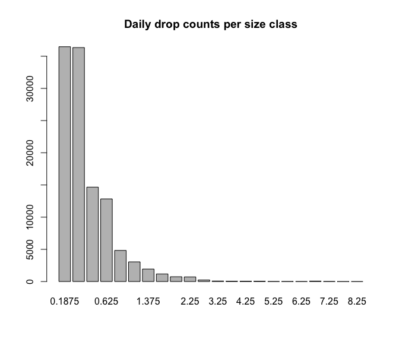

```r
barplot(colSums(day), main='Daily drop counts per size class')
```

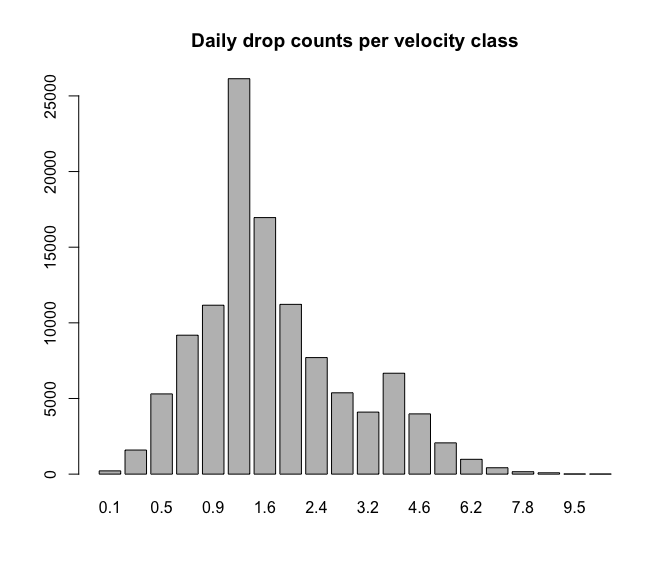

```r
barplot(rowSums(day), main='Daily drop counts per velocity class')
```

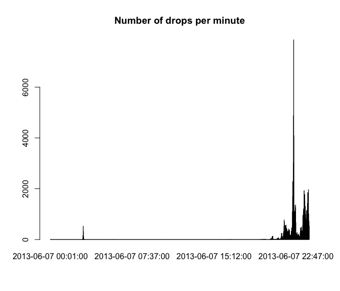

```r
time <- apply(DSVD, 1, sum)
barplot(time, main='Number of drops per minute')
```

The function `dsd_plot()` produces a drop count velocity vs. size plot from the DSVD data. The function interprets DSVD matrices from either Thies LPM or OTT Parsivel devices, being `Thies` the default option.

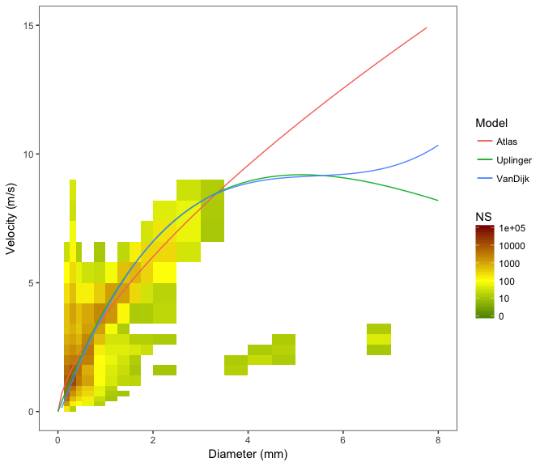

```r
dsd_plot(day, type='Thies')
```

It is possible to choose the theoretical models to plot on top of the DSVD data:

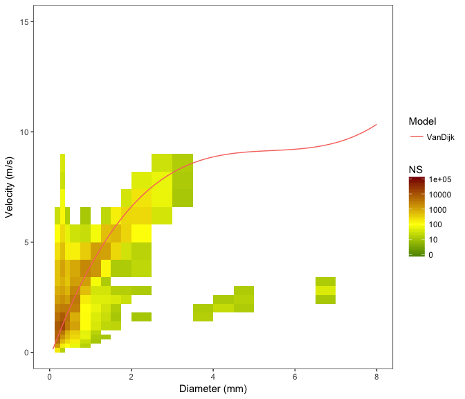

```r
dsd_plot(day, model='VanDijk')
```

Or to plot no models at all:

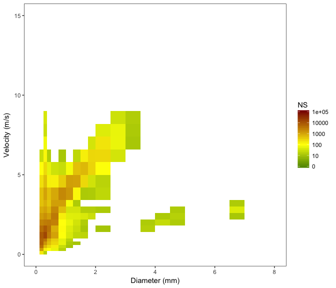

```r
dsd_plot(day, model=NA)
```

The size of the bins in the previous plot correspond to those of the raw matrix yielded by the disdrometer. Interpolated 2D desnity contour lines can be plotted on top by setting parameter `contour` to TRUE:

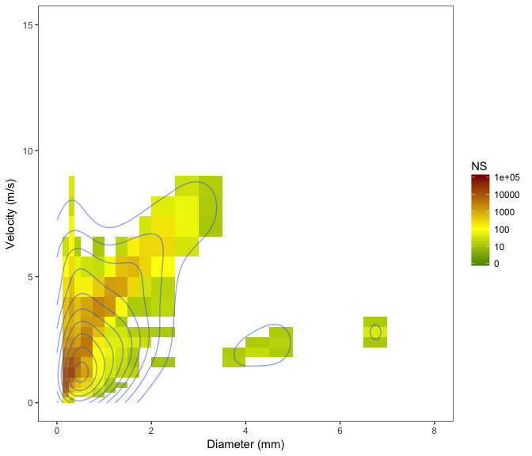

```r
dsd_plot(day, model=NA, contour=TRUE)
```

Finally, there is an option to produce the plots in black and white, setting theme=‘bw’.

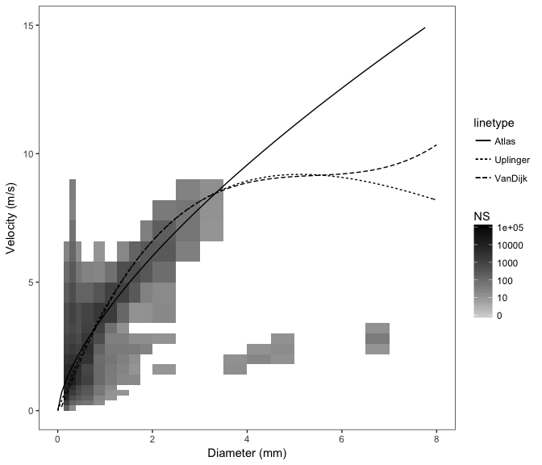

```r
dsd_plot(day, theme='bw')
```

## Example with Parsivel data

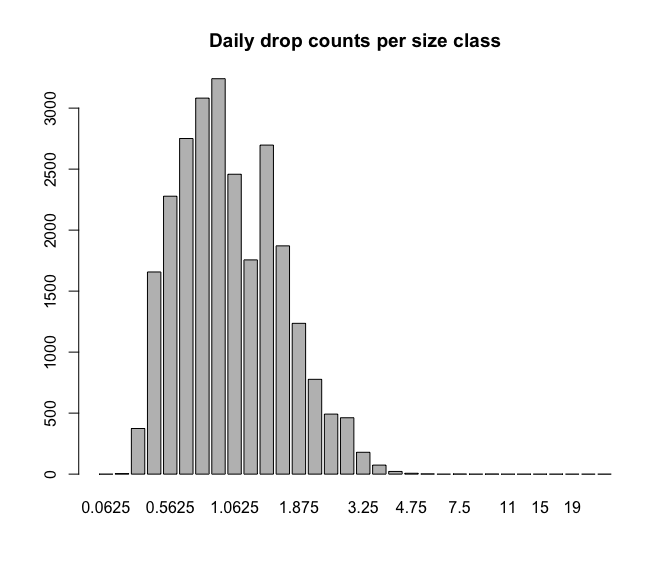

```r
f <- system.file('extdata', 'rawDataParsivel', package='disdRo')
files <- list.files(f, '.txt.gz', full.names=TRUE, recursive=TRUE)
DSVD <- dsd_read(files, type='Parsivel')

day <- apply(DSVD, c(2,3), sum)
barplot(colSums(day), main='Daily drop counts per size class')
```

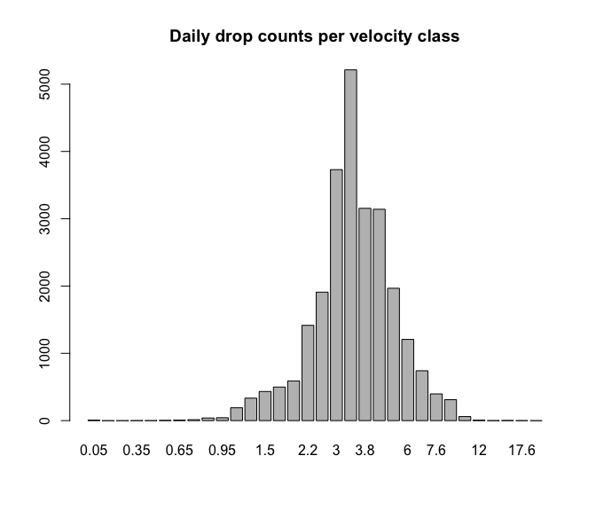

```r
barplot(rowSums(day), main='Daily drop counts per velocity class')
```

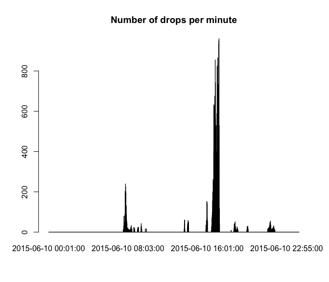

```r
time <- apply(DSVD, 1, sum)
barplot(time, main='Number of drops per minute')
```

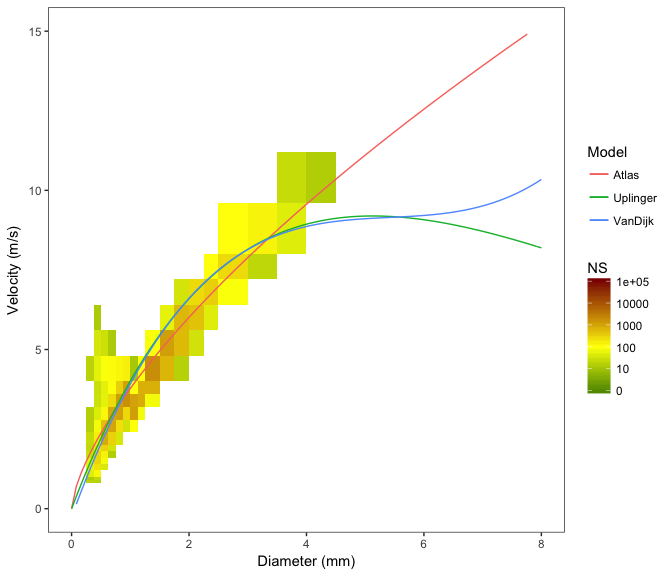

```r
dsd_plot(day, type='Parsivel')
```

## To do list

- A function to calculate the number density / drop concentration (1 m-3 mm-1)
- All the files need to conform to the format expected from the disdrometer; there are frequent errors, especially on Parsivel files, that cause the function to fail.

# Working with the integrated variables

So far we have worked with the raw disdrometric matrix, or DSVD, but the disdrometers also offer a series of integrated variables which are calculated upon the raw matrix. These include the precipitation intensity and cumulative amounts, the kinetic energy released, the radar reflectivity, and others. The function `dsd_integrate()` enables automatic and fast computation of disdrometer integrated variables from raw disdrometer files. It also performs a quality control, and reports on several status variables recorded by the disdrometer.

Currently, this is done via an external Perl script, so you need to have Perl installed and working in your system. Beware: some users have reported issues for running the Perl script in Windows. It might be translated into a native R script in the future, if I find time to do it. The script `process.pl` can be found in the directory where the `disdRo` package was installed. The perl script can be used in stand-alone way as follows:

`perl process.pl directory outfile (middle|uniform|linear)`

The first argument invokes the Perl interpreter, the second argument points to the location of the script we want to run, the third argument points to the directory containing the disdrometer data, and the fourth argument provides a name of the output file to store the results. In addition, it is possible to choose between `middle`, `uniform`, and `linear`, which are different methods for estimating the distribution of drop sizes and velocities within the limits of the bins in which the DSVD matrix is divided (more on this later).

To use the `dsd_integrate()` function:

```r
?dsd_integrate

f <- system.file('extdata', 'rawDataThies', package='disdRo')
int <- dsd_integrate(f)
summary(int)
```

```
  type          serial         time
 Thi:1440   Min.   :436   Min.   :2013-06-07 00:00:00
            1st Qu.:436   1st Qu.:2013-06-07 05:59:45
            Median :436   Median :2013-06-07 11:59:30
            Mean   :436   Mean   :2013-06-07 11:59:30
            3rd Qu.:436   3rd Qu.:2013-06-07 17:59:15
            Max.   :436   Max.   :2013-06-07 23:59:00

    seconds              synop             r                 p
 Min.   :1.371e+09   Min.   : 0.00   Min.   : 0.0000   Min.   :0.000000
 1st Qu.:1.371e+09   1st Qu.: 0.00   1st Qu.: 0.0000   1st Qu.:0.000000
 Median :1.371e+09   Median : 0.00   Median : 0.0000   Median :0.000000
 Mean   :1.371e+09   Mean   :10.05   Mean   : 0.4175   Mean   :0.006959
 3rd Qu.:1.371e+09   3rd Qu.: 0.00   3rd Qu.: 0.0000   3rd Qu.:0.000000
 Max.   :1.371e+09   Max.   :88.00   Max.   :33.6200   Max.   :0.560400
                     NA's   :4       NA's   :4         NA's   :4
       m                   z                 e               mor
 Min.   :-1.000000   Min.   :-26.820   Min.   : 0.000   Min.   :      0
 1st Qu.: 0.000000   1st Qu.:  0.000   1st Qu.: 0.000   1st Qu.:      0
 Median : 0.000000   Median :  0.000   Median : 0.000   Median :      0
 Mean   :-0.006964   Mean   :  4.389   Mean   : 1.492   Mean   : 147357
 3rd Qu.: 0.000000   3rd Qu.:  0.000   3rd Qu.: 0.000   3rd Qu.:      0
 Max.   : 1.000000   Max.   : 58.420   Max.   :24.190   Max.   :8759000
 NA's   :4           NA's   :4         NA's   :4        NA's   :4
     r_meas            z_meas           e_meas     mor_meas
 Min.   : 0.0000   Min.   :-9.900   Min.   :0   Min.   :  677
 1st Qu.: 0.0000   1st Qu.:-9.900   1st Qu.:0   1st Qu.:99999
 Median : 0.0000   Median :-9.900   Median :0   Median :99999
 Mean   : 0.4399   Mean   :-4.936   Mean   :0   Mean   :90308
 3rd Qu.: 0.0000   3rd Qu.:-9.900   3rd Qu.:0   3rd Qu.:99999
 Max.   :33.3470   Max.   :41.600   Max.   :0   Max.   :99999
 NA's   :4         NA's   :4        NA's   :4   NA's   :4
      qual             tmp          rh          w           wd
 Min.   : 50.00   Min.   :0   Min.   :0   Min.   :0   Min.   :0
 1st Qu.:100.00   1st Qu.:0   1st Qu.:0   1st Qu.:0   1st Qu.:0
 Median :100.00   Median :0   Median :0   Median :0   Median :0
 Mean   : 98.81   Mean   :0   Mean   :0   Mean   :0   Mean   :0
 3rd Qu.:100.00   3rd Qu.:0   3rd Qu.:0   3rd Qu.:0   3rd Qu.:0
 Max.   :100.00   Max.   :0   Max.   :0   Max.   :0   Max.   :0
 NA's   :4        NA's   :4   NA's   :4   NA's   :4   NA's   :4
```

[output cut: 32 more lines]

```
      v90             vmean           t_shift       now
 Min.   :0.0000   Min.   :0.0000   Min.   :0   Min.   : 0.00
 1st Qu.:0.0000   1st Qu.:0.0000   1st Qu.:0   1st Qu.:15.00
 Median :0.0000   Median :0.0000   Median :0   Median :30.00
 Mean   :0.7211   Mean   :0.4491   Mean   :0   Mean   :29.54
 3rd Qu.:0.0000   3rd Qu.:0.0000   3rd Qu.:0   3rd Qu.:44.25
 Max.   :6.7920   Max.   :4.6000   Max.   :0   Max.   :60.00
 NA's   :4        NA's   :4        NA's   :4   NA's   :4
      err                ncol
 Min.   :0.000000   Min.   :  0.0
 1st Qu.:0.000000   1st Qu.:524.0
 Median :0.000000   Median :524.0
 Mean   :0.002778   Mean   :522.5
 3rd Qu.:0.000000   3rd Qu.:524.0
 Max.   :1.000000   Max.   :524.0
```

Explanation of the variables in the data frame:

| Num | Nombre | Descripción | Parsivel | Thies |
| --- | --- | --- | --- | --- |
| 1 | type | modelo del aparato | Si | Si |
| 2 | serial | número de serie del aparato | Si | Si |
| 3 | time | fecha y hora de la observación (POSIXct) | Si | Si |
| 4 | seconds | número de segundos desde 1970-01-01 00:00:00 | Si | Si |
| 5 | synop | SYNOP code 4677 | Si | Si |
| 6 | r | calculated rain intensity, mm h-1 | Si | Si |
| 7 | p | calculated precipitation amount, mm | Si | Si |
| 8 | m | calculated water content, g m3 | Si | Si |
| 9 | z | calculated radar reflectivity, dB mm6 m-3 | Si | Si |
| 10 | e | calculated kynetic energy, J m-2 mm-1 | Si | Si |
| 11 | mor | calculated MOR visibility, m | Si | Si |
| 12 | r_meas | measured rain intensity, mm h-1 | Si | Si |
| 13 | z_meas | measured radar reflectivity, dB mm6 m-3 | Si | Si |
| 14 | e_meas | measured kynetic energy, J m-2 mm-1 | Si | No |
| 15 | mor_meas | measured MOR visibility, m | Si | Si |
| 16 | qual | data quality, % | No | Si |
| 17 | tmp | air temperature, ºC | No | Opt |
| 18 | rh | relative air humidity, % | No | Opt |
| 19 | w | wind velocity, m/s | No | Opt |
| 20 | wd | wind direction, º | No | Opt |
| 21 | np | number of particles detected (-) | Si | Si |
| 22 | power | sensor power supply (V) | Si | Si |
| 23 | tmp_int | internal (sensor) temperature (ºC) | Si | Si |
| 24 | d25 | drop diameter, 25 percentile (mm) | Si | Si |
| 25 | d50 | drop diameter, 50 percentile (mm) | Si | Si |
| 26 | d75 | drop diameter, 75 percentile (mm) | Si | Si |
| 27 | dmean | average drop diameter (mm) | Si | Si |
| 28 | v25 | drop velocity, 25 percentile (m/s) | Si | Si |
| 29 | v50 | drop velocity, 50 percentile (m/s) | Si | Si |
| 30 | v75 | drop velocity, 75 percentile (m/s) | Si | Si |
| 31 | vmean | average drop velocity (m/s) | Si | Si |
| 32 | t_shift | telegram time shift (s) | Si | Si |
| 33 | nrow | telegram line number | Si | Si |
| 34 | err | error status code (0, no error; 1, no data) | Si | Si |
| 35 | ncol | number of telegram fields | Si | Si |

An NA value is obtained if the variable does not exist in the telegram.

List of the error codes:

| Código | Descripción |
| --- | --- |
| 0 | Sin error |
| 1 | No hay telegrama para ese minuto |
| 2 | Saturación en la matriz de los Thies |
| 3 | Caracteres extraños en código SYNOP |
| 4 | Caracteres extraños en rain intensity |
| 5 | 9999.999 en rain intensity |
| 6 | El telegrama sólo contiene ‘OK’ o ‘Version’ (¿reinicio del Parsivel?) |
| 7 | Caracteres extraños en el telegrama |
| 21-23 | Parsivel error codes 1 to 3 |
| 24-36 | Thies error codes 24 to 36 |
| 37 | Thies, multiple error codes |

It is easy to plot the different variables:

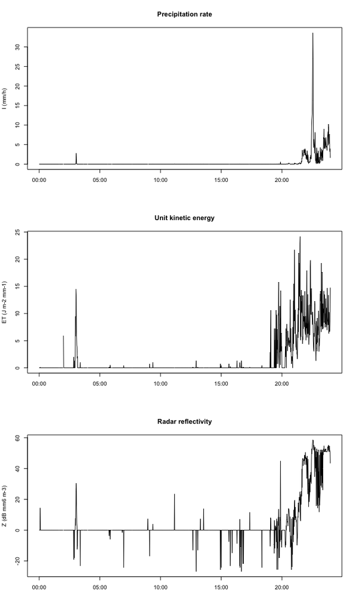

```r
par(mfrow=c(3,1))
plot(int$r~int$time, type='l', xlab='', ylab='I (mm/h)',
     main='Precipitation rate')
plot(int$e~int$time, type='l', xlab='', ylab='ET (J m-2 mm-1)',
     main='Unit kinetic energy')
plot(int$z~int$time, type='l', xlab='', ylab='Z (dB mm6 m-3)',
     main='Radar reflectivity')
```

The output of `dsd_integrate()` contains the integrated variables computed from the raw DSVD matrix, but also the same variables computed internally by the disdrometer and reported in the telegram (if they exist). These are distinguished by the suffix `_meas`.

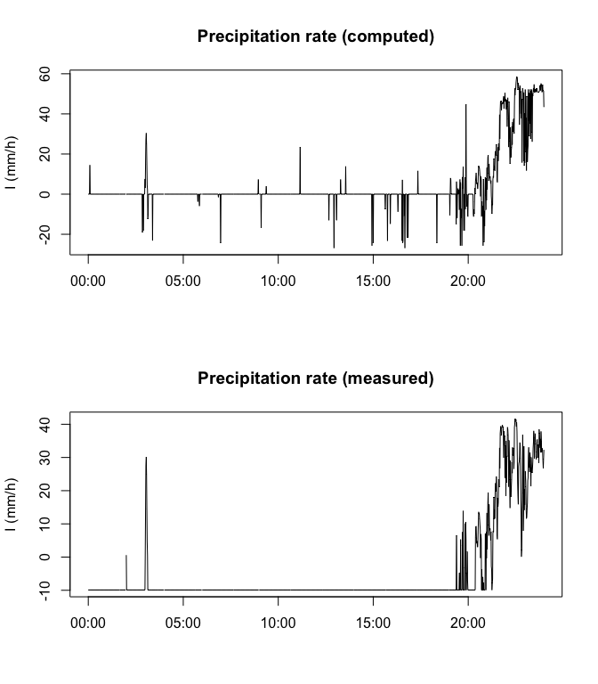

```r
par(mfrow=c(2,1))
plot(int$z~int$time, type='l', xlab='', ylab='I (mm/h)',
     main='Precipitation rate (computed)')
plot(int$z_meas~int$time, type='l', xlab='', ylab='I (mm/h)',
     main='Precipitation rate (measured)')
```

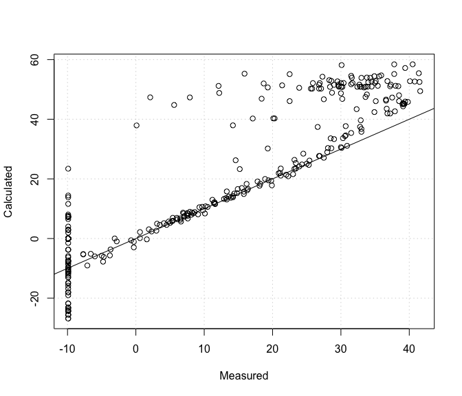

```r
par(mfrow=c(1,1))
plot(int$z~int$z_meas, ylab='Calculated', xlab='Measured')
grid()
abline(0,1)
```

By converting the output object (a `data.frame`) to a temporal series object of class `zoo`, it is easy to perform operations using the time as an index variable, for instance extracting a specific event for which we know the starting and ending times:

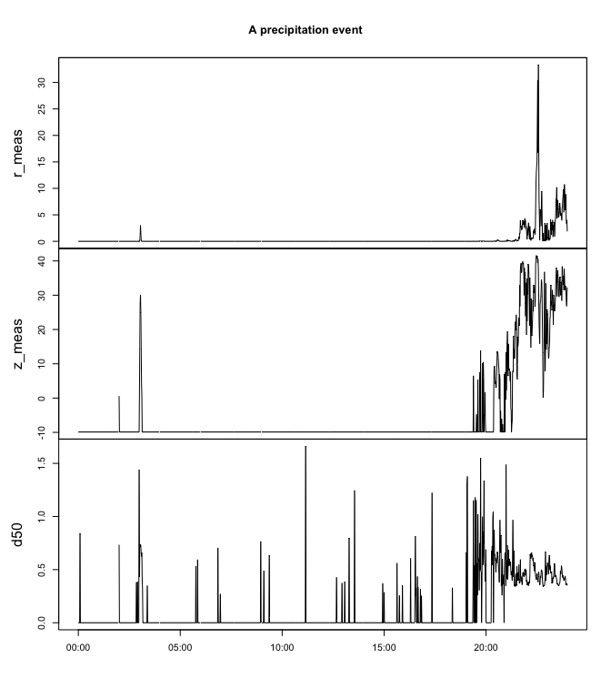

```r
library(zoo)
int <- zoo(int[,-c(1:3)], int$time)

event <- window(int, start='2013-06-07 28:00:00', end='2013-06-07 23:59:00')
plot(event[,c('r_meas','z_meas','d50')], type='l',
     xlab='', main='A precipitation event')
```

## To do list

- Integrate the call to the perl script in a wrapper function in R.